# Estudios de Informática, Multimedia y Telecomunicaciones

# Estadística Avançada

Autor: Jordi Puig Ovejero

Maig 2021

Carrega de les llibreries que es necessiten

```r
library(dplyr)
library(base)
library(matrixStats)
library(stringr)
library(ggplot2)
library(lubridate)
library(eeptools)
library(psych)
library(corrplot)
library(factoextra)
library(ggbiplot)
library(ggpubr)
library(rlang)
library(kableExtra)
library(ResourceSelection)
library(pROC)
library(data.table)
library(nortest)
library(caret)
library(agricolae)
library(sjmisc)
library(MASS)
library(psych)
```

# 1 Introducció

En aquest darrer exercici anem a estudiar les indemnitzacions per baixa laboral atorgades per una companyia d’assegurançes al llarg del temps.

El conjunt de dades té els següents atributs:

## 1.1 Definició dels atributs

- ClaimNumber: Identificador de la pòlissa.
- DateTimeOfAccident: Data de l’accident.
- DateReported: Data que es comunica a la companyia i aquesta obre un expedient del sinistre (obertura).
- Age: Edat del treballador.
- Gender: Sexe.
- MaritalStatus: Estat civil, (M)arried, (S)ingle, (U)nknown.
- DependentChildren: Nombre de fills dependents.
- DependentsOther: Nombre de dependents excloent fills
- WeeklyWages: Salari setmanal (en EUR).
- PartTimeFullTime: Jornada laboral, Part time (P) o Full time(F).
- HoursWorkedPerWeek: Nombre d’hores per setmana.
- DaysWorkedPerWeek: Nombre de dies per setmana.
- ClaimDescription: Descripció sinistres.
- InitialIncurredClaimCost: Estimació inicial del cost realitzat per la companyia.
- UltimateIncurredClaimCost: Cost total pagat per sinistre.

# 2 Lectura del fitxer i preparació de les dades

El fitxer on es troba el dataset és, **trainClean.csv**:

Carreguem les dades i fem un summary d’aquestes.

```r
insurance <- read.csv('trainClean.csv',stringsAsFactors = TRUE, sep = ',')
attach(insurance) # ens permet referenciar les columnes de fifa sense haver d'especificar el dataset.
summary(insurance)
```

```
##     ClaimNumber               DateTimeOfAccident               DateReported
##  WC1592889:    1   1991-02-19T11:00:00Z:    9    2001-03-29T00:00:00Z:   25
##  WC1592905:    1   2001-05-01T14:00:00Z:    9    1997-09-11T00:00:00Z:   22
##  WC1592998:    1   1993-03-22T11:00:00Z:    8    2000-11-22T00:00:00Z:   22
##  WC1593292:    1   1988-05-23T10:00:00Z:    7    1991-10-24T00:00:00Z:   21
##  WC1593727:    1   1989-10-20T09:00:00Z:    7    2005-02-24T00:00:00Z:   21
##  WC1593868:    1   1989-10-25T10:00:00Z:    7    2001-07-12T00:00:00Z:   20
##  (Other)  :53994   (Other)             :53953    (Other)             :53869
##       Age        Gender    MaritalStatus DependentChildren DependentsOther
##  Min.   :13.00   F:12338    :   29       Min.   :0.0000    Min.   :0.000000
##  1st Qu.:23.00   M:41660   M:22516       1st Qu.:0.0000    1st Qu.:0.000000
##  Median :32.00   U:    2   S:26161       Median :0.0000    Median :0.000000
##  Mean   :33.84             U: 5294       Mean   :0.1192    Mean   :0.009944
##  3rd Qu.:43.00                           3rd Qu.:0.0000    3rd Qu.:0.000000
##  Max.   :81.00                           Max.   :9.0000    Max.   :5.000000
##
##   WeeklyWages     PartTimeFullTime HoursWorkedPerWeek DaysWorkedPerWeek
##  Min.   :   1.0   F:49112          Min.   :  0.00     Min.   :1.000
##  1st Qu.: 200.0   P: 4888          1st Qu.: 38.00     1st Qu.:5.000
##  Median : 392.2                    Median : 38.00     Median :5.000
##  Mean   : 416.4                    Mean   : 37.74     Mean   :4.906
##  3rd Qu.: 500.0                    3rd Qu.: 40.00     3rd Qu.:5.000
##  Max.   :7497.0                    Max.   :640.00     Max.   :7.000
##
##                                       ClaimDescription
##  SLIPPED ON ROLLER TENDONITIS RIGHT SHOULDER  :  289
##  SORTING ALUMINIUM BARS STRAIN SHOULDER NECK  :  278
##  SLIPPED USING LATHE IN EYE CORNEA            :  258
##  REDBACK SPIDER BITE RIGHT FOOT RIGHT FRACTURE:  256
##  LIFTING TYRES LOWER BACK STRAIN              :  255
##  LIFTING BACK STRAIN LOWER BACK STRAIN        :  253
##  (Other)                                      :52411
##  InitialIncurredCalimsCost UltimateIncurredClaimCost
##  Min.   :      1           Min.   :      5.7
##  1st Qu.:    700           1st Qu.:   1128.7
##  Median :   2000           Median :   3179.1
##  Mean   :   7841           Mean   :  10195.5
##  3rd Qu.:   9500           3rd Qu.:   8900.1
##  Max.   :2000000           Max.   :1570535.8
##
```

Contem les files i columnes que tenim.

```r
cat('Tenim un total de', ncol(insurance), 'columnes\n')
```

```
## Tenim un total de 15 columnes
```

```r
cat('Tenim un total de', nrow(insurance), 'registres')
```

```
## Tenim un total de 54000 registres
```

I mostrem els valors NA per cada atribut.

```r
colSums(is.na(insurance))
```

```
##               ClaimNumber        DateTimeOfAccident              DateReported
##                         0                         0                         0
##                       Age                    Gender             MaritalStatus
##                         0                         0                         0
##         DependentChildren           DependentsOther               WeeklyWages
##                         0                         0                         0
##          PartTimeFullTime        HoursWorkedPerWeek         DaysWorkedPerWeek
##                         0                         0                         0
##          ClaimDescription InitialIncurredCalimsCost UltimateIncurredClaimCost
##                         0                         0                         0
```

Finalment fem un head dels atributs a tractar.

```r
head(insurance)
```

```
##   ClaimNumber   DateTimeOfAccident         DateReported Age Gender
## 1   WC8285054 2002-04-09T07:00:00Z 2002-07-05T00:00:00Z  48      M
## 2   WC6982224 1999-01-07T11:00:00Z 1999-01-20T00:00:00Z  43      F
## 3   WC5481426 1996-03-25T00:00:00Z 1996-04-14T00:00:00Z  30      M
## 4   WC9775968 2005-06-22T13:00:00Z 2005-07-22T00:00:00Z  41      M
## 5   WC2634037 1990-08-29T08:00:00Z 1990-09-27T00:00:00Z  36      M
## 6   WC6828422 1999-06-21T11:00:00Z 1999-09-09T00:00:00Z  50      M
##   MaritalStatus DependentChildren DependentsOther WeeklyWages PartTimeFullTime
## 1             M                 0               0      500.00                F
## 2             M                 0               0      509.34                F
## 3             U                 0               0      709.10                F
## 4             S                 0               0      555.46                F
## 5             M                 0               0      377.10                F
## 6             M                 0               0      200.00                F
##   HoursWorkedPerWeek DaysWorkedPerWeek
```

[output cut: 20 more lines]

## 2.1 Preparació de les dades

### 2.1.1 Canvi de nom de les variables

Passem el nom de les variables al castellà. Fem servir la funció setnames de llibreria data.table.

```r
setnames(insurance,"ClaimNumber", "Id")
setnames(insurance,"DateTimeOfAccident", "Ocurrencia")
setnames(insurance,"DateReported", "Apertura")
setnames(insurance,"Age", "Edad")
setnames(insurance,"Gender", "Sexo")
setnames(insurance,"MaritalStatus", "Estado")
setnames(insurance,"DependentChildren", "Dependientes")
setnames(insurance,"DependentsOther", "OtrosDepend")
setnames(insurance,"WeeklyWages", "Salario")
setnames(insurance,"PartTimeFullTime", "Jornada")
setnames(insurance,"InitialIncurredCalimsCost", "CosteInicio")
setnames(insurance,"UltimateIncurredClaimCost", "CosteFinal")
setnames(insurance,"HoursWorkedPerWeek", "HorasSemana")
setnames(insurance,"DaysWorkedPerWeek", "DiasSemana")
setnames(insurance,"ClaimDescription", "Descripcion")

colnames(insurance)
```

```
##  [1] "Id"           "Ocurrencia"   "Apertura"     "Edad"         "Sexo"
##  [6] "Estado"       "Dependientes" "OtrosDepend"  "Salario"      "Jornada"
## [11] "HorasSemana"  "DiasSemana"   "Descripcion"  "CosteInicio"  "CosteFinal"
```

### 2.1.2 Conversió de tipus de Occurrencia i Apertura a tipus Date

```r
# efectivament Occurencia i Apertura están com a Factor
class(insurance$Ocurrencia)
```

```
## [1] "factor"
```

```r
head(insurance$Ocurrencia)
```

```
## [1] 2002-04-09T07:00:00Z 1999-01-07T11:00:00Z 1996-03-25T00:00:00Z
## [4] 2005-06-22T13:00:00Z 1990-08-29T08:00:00Z 1999-06-21T11:00:00Z
## 36673 Levels: 1988-01-01T09:00:00Z 1988-01-01T13:00:00Z ... 2005-12-31T10:00:00Z
```

```r
# passem a Data
insurance$Ocurrencia <- as.Date(insurance$Ocurrencia, format="%Y-%m-%dT%H:%M:%SZ")
class(insurance$Ocurrencia)
```

```
## [1] "Date"
```

```r
head(insurance$Ocurrencia)
```

```
## [1] "2002-04-09" "1999-01-07" "1996-03-25" "2005-06-22" "1990-08-29"
## [6] "1999-06-21"
```

```r
# fem el mateix amb Apertura
class(insurance$Apertura)
```

```
## [1] "factor"
```

```r
head(insurance$Apertura)
```

```
## [1] 2002-07-05T00:00:00Z 1999-01-20T00:00:00Z 1996-04-14T00:00:00Z
## [4] 2005-07-22T00:00:00Z 1990-09-27T00:00:00Z 1999-09-09T00:00:00Z
## 6653 Levels: 1988-01-08T00:00:00Z 1988-01-10T00:00:00Z ... 2006-09-23T00:00:00Z
```

```r
# passem a Data
insurance$Apertura <- as.Date(insurance$Apertura, format="%Y-%m-%dT%H:%M:%SZ")
class(insurance$Apertura)
```

```
## [1] "Date"
```

```r
head(insurance$Apertura)
```

```
## [1] "2002-07-05" "1999-01-20" "1996-04-14" "2005-07-22" "1990-09-27"
## [6] "1999-09-09"
```

### 2.1.3 Crear variable Tiempo

Per crear la variable tiempo calculem els dies entre la Ocurrencia i la Apertura,

```r
insurance$Tiempo <- age_calc(insurance$Ocurrencia, enddate = insurance$Apertura, units = "days")
head(insurance$Tiempo)
```

```
## Time differences in days
## [1] 87 13 20 30 29 80
```

```r
insurance$Tiempo <- as.integer(insurance$Tiempo)
```

## 2.2 Classificació del temps

En aquest cas donem un valor a Clasificacion segons el valor que hem calculat previament a Tiempo.

```r
insurance$Clasificacion <- ''
insurance$Clasificacion <- ifelse(insurance$Tiempo >= 90, 'Molt lent', insurance$Clasificacion)
insurance$Clasificacion <- ifelse(insurance$Tiempo <= 89 & insurance$Tiempo >= 31, 'Lent', insurance$Clasificacion)
insurance$Clasificacion <- ifelse(insurance$Tiempo <= 30 & insurance$Tiempo >= 16, 'Rapid', insurance$Clasificacion)
insurance$Clasificacion <- ifelse(insurance$Tiempo < 16, 'Molt Rapid', insurance$Clasificacion)
insurance$Clasificacion <- as.factor(insurance$Clasificacion)
```

## 2.3 Valors absents

Analitzem el nombre de categories a ‘Descripcion‘, ‘Sexo‘ i ‘Estado‘:

```r
## Descripcion
nlevels(insurance$Descripcion)
```

```
## [1] 28114
```

```r
## Sexo
summary(insurance$Sexo)
```

```
##     F     M     U
## 12338 41660     2
```

```r
## Estado
summary.factor(insurance$Estado)
```

```
##           M     S     U
##    29 22516 26161  5294
```

Hem mostrat els levels de Sexo i Estado i veiem que tenim valors U (Undefined) o valors buïts.

Per a description només he comptabilitzat la qüantitat de levels ja que hi han moltíssims levels (28114). Entenc que en el formulari a l’introduir-ho d’entrada deu ser un camp de tipus text lliure.

```r
insurance$Sexo[insurance$Sexo== "U"] <- NA
insurance$Estado[insurance$Estado== "U"] <- NA
insurance$Estado[insurance$Estado== ""] <- NA
colSums(is.na(insurance))
```

```
##            Id    Ocurrencia      Apertura          Edad          Sexo
##             0             0             0             0             2
##        Estado  Dependientes   OtrosDepend       Salario       Jornada
##          5323             0             0             0             0
##   HorasSemana    DiasSemana   Descripcion   CosteInicio    CosteFinal
##             0             0             0             0             0
##        Tiempo Clasificacion
##             0             0
```

```r
cat('Tenim un ', 2/nrow(insurance) * 100, '% de NA a Sexo\n')
```

```
## Tenim un  0.003703704 % de NA a Sexo
```

```r
cat('Tenim un ', (5294+2)/nrow(insurance) * 100, '% de NA a Estado')
```

[output not shown]

Tenim quasi un 10% de valors NA’s a Estado i a Sexo la quantitat és insignificant. Realment el que jo faria seria eliminar els registres a Sexo. A Estado podriem fer una imputació de valors mitjançant per exemple l’algoritme de Knn (trobem els veins propers a partir dels altres atributs i atorguem un valor).

L’exercici demana eliminar els valors absents i això és el que farem.

```r
claimNet <- subset(insurance, !is.na(insurance$Sexo))
# esborrem els levels buïts
claimNet$Sexo <- droplevels(claimNet$Sexo)

claimNet <- subset(claimNet, !is.na(claimNet$Estado))
# esborrem els levels buïts
claimNet$Estado <- droplevels(claimNet$Estado)

colSums(is.na(claimNet))
```

```
##            Id    Ocurrencia      Apertura          Edad          Sexo
##             0             0             0             0             0
##        Estado  Dependientes   OtrosDepend       Salario       Jornada
##             0             0             0             0             0
##   HorasSemana    DiasSemana   Descripcion   CosteInicio    CosteFinal
##             0             0             0             0             0
##        Tiempo Clasificacion
##             0             0
```

```r
cat('Hem eliminat un ', (nrow(insurance) - nrow(claimNet)) / nrow(insurance) * 100, '% de registres')
```

```
## Hem eliminat un  9.861111 % de registres
```

## 2.4 Salut mental

Creem la variable RiesgoSM que és 1 si Descripcion conté les paraules ‘Stress, Anxiety, Harassment o Depression’ altrament serà 0.

```r
custom_regex <- function(sentence) {
  strings <- c("Stress", "Anxiety", "Harassment", "Depression")
  output <- 0
  for (value in strings) {
    if (str_contains(strsplit(sentence, " "), value, ignore.case = TRUE, logic = "OR", switch = FALSE)) {
      output <- 1
    }
  }
  return <- output
}

claimNet$RiesgoSM <- lapply(as.character(claimNet[,13]), custom_regex)
claimNet$RiesgoSM <- as.factor(as.integer(claimNet$RiesgoSM))
summary(claimNet$RiesgoSM)
```

```
##     0     1
## 48459   216
```

## 2.5 Anàlisi visual

Anem a fer un analísi visual de la variable CosteFinal (cost final dels diners percebuts) respecte:

### 2.5.1 Sexe

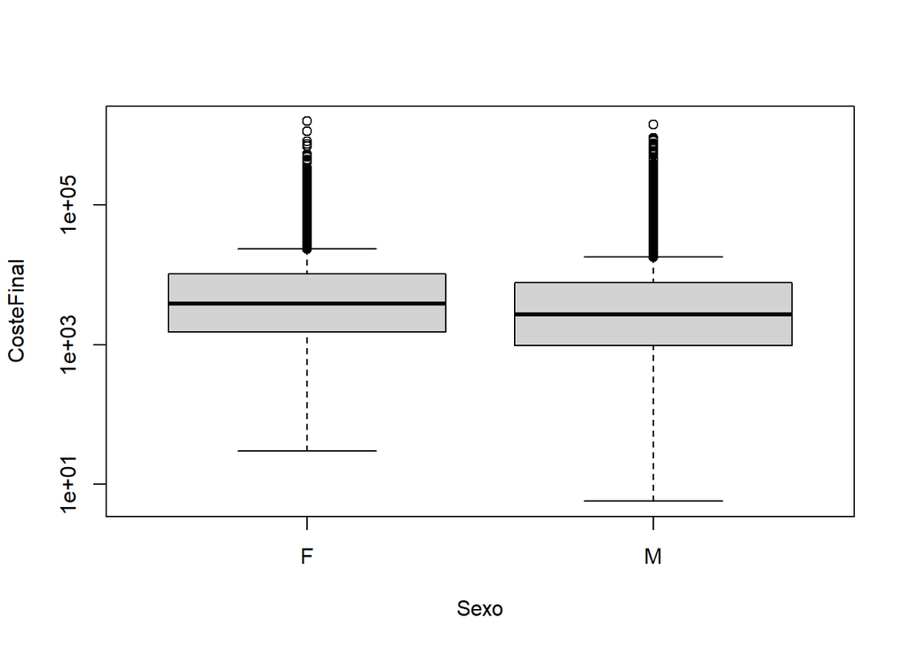

```r
boxplot(CosteFinal ~ Sexo, data = claimNet, log = "y")
```

En general tant la mitjana, com el Q1 i Q3, mínim i màxim, sembla que el percebut per el sexe Femení sigui llegeurament superior al masculí.

### 2.5.2 Estado

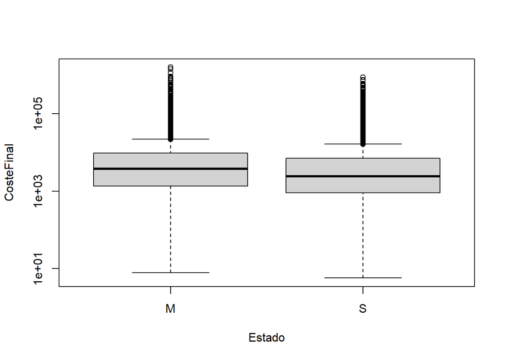

```r
boxplot(CosteFinal ~ Estado, data = claimNet, log = "y")
```

### 2.5.3 Clasificacion

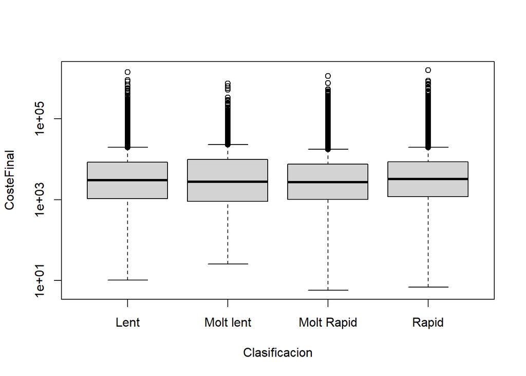

```r
boxplot(CosteFinal ~ Clasificacion, data = claimNet, log = "y")
```

La velocitat en el tràmit en l’expedició del sinistre no sembla molt rellevat. Potser els tràmits més ràpids (menys temps entre que succeeix i s’obre expedient) són els que tenen un import més elevat.

### 2.5.4 RiesgoSM

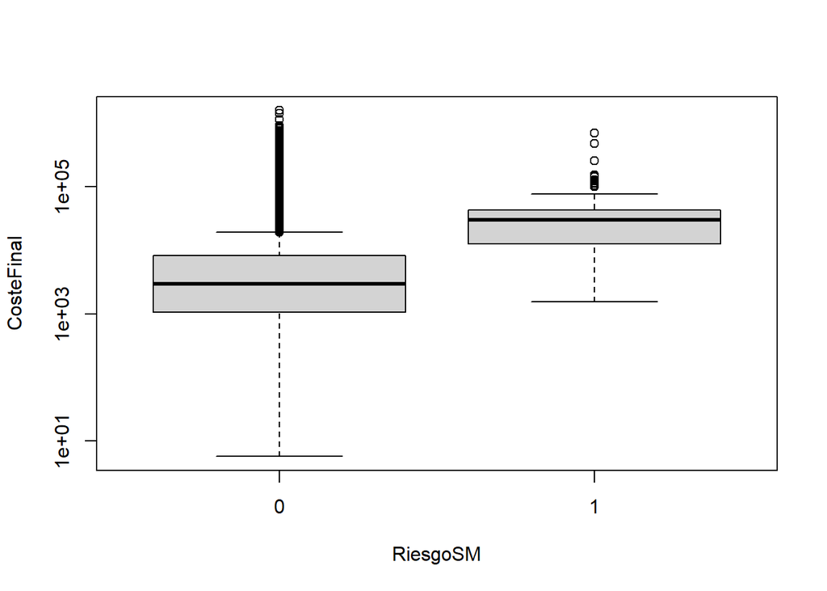

```r
boxplot(CosteFinal ~ RiesgoSM, data = claimNet, log = "y")
```

Finalment on si és veu realment una diferència molt clara és amb la tipologia del sinistres. Si és per temes mentals tenen un import final molt més alt que no pas la resta.

Resumint, segons els boxplot que hem pogut veure: per a l’assegurança, el pitjor cas seria un sinistre d’una dona, casada i amb malaltia mental, de cara a la despesa final.

## 2.6 Comprovació de normalitat

Fem una comprovació de la normalitat de la variable CosteFinal:

### 2.6.1 Anàlisi visual

```r
summary(claimNet$CosteFinal)
```

```
##      Min.   1st Qu.    Median      Mean   3rd Qu.      Max.
##       5.7    1067.9    2982.0    9704.6    8349.6 1570535.8
```

Amb el summary veiem que la mediana és 2982, força allunyat de la mitja 9704.6. Tenim valor força allunyats dels 1Q i sobretot del 3Q amb el que podriem estar davant de outliers.

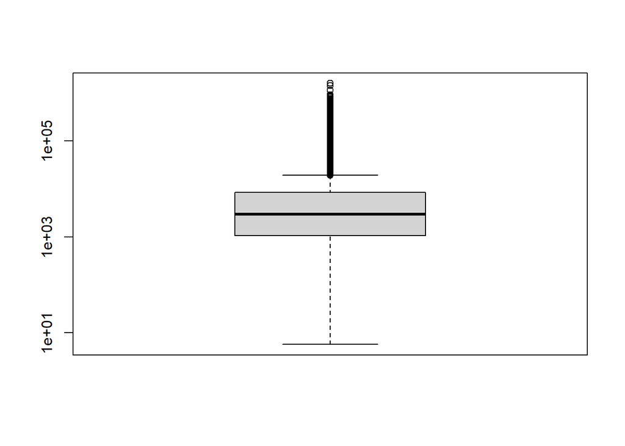

```r
boxplot(claimNet$CosteFinal, data = claimNet, log = "y")
```

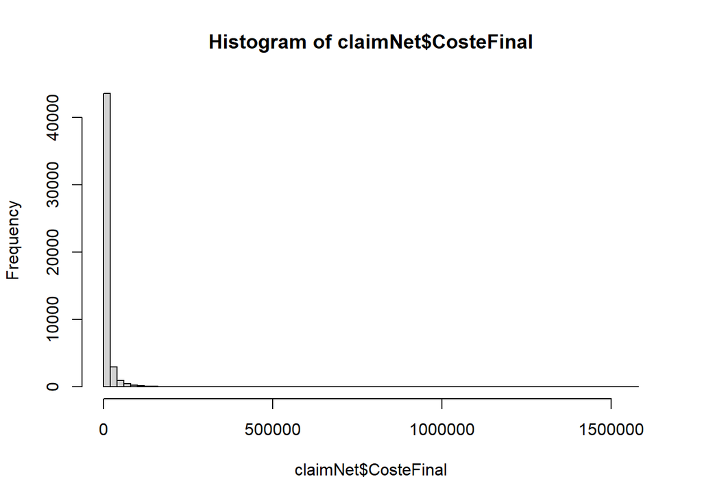

```r
hist(claimNet$CosteFinal, breaks=100)
```

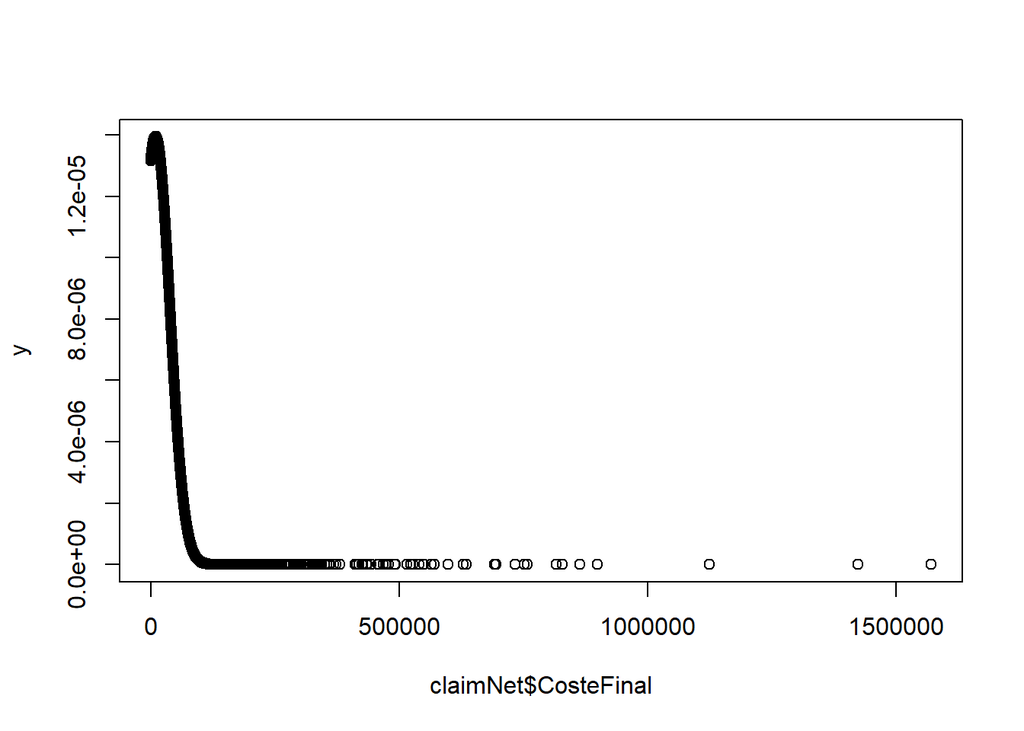

```r
y = dnorm(claimNet$CosteFinal, mean(claimNet$CosteFinal), sd(claimNet$CosteFinal))
plot(claimNet$CosteFinal, y)
```

Tant amb l’histograma o plot anterior no veiem la clàssica corva normal però tenim una corva assimptòtica com la mostrada amb el que probablement sigui una distribució lognormal.

### 2.6.2 Anàlisi de normalitat de Lilliefors

Al igual que el test de normalitat Shapiro-Wilk, es treballa amb la hipòtesi nul·la de normalitat de dades. Valors de p per sota del nivell de significança rebutjen la hipòtesi nul·la i per tant descartem la normalitat.

```r
lillie.test(claimNet$CosteFinal)
```

```
##
##  Lilliefors (Kolmogorov-Smirnov) normality test
##
## data:  claimNet$CosteFinal
## D = 0.36734, p-value < 2.2e-16
```

Segons el test, tenim un val0r per tota de 0.05 i hem de rebutjar la hipòtesi nul·la de normalitat de les dades en l’atribut CosteFinal.

### 2.6.3 Anàlisi en escala logarítimica

Amb el boxplot en escala logaritmica podem veure la distribució normal de forma visual.

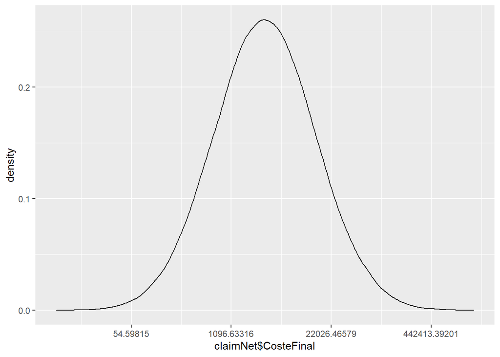

```r
ggplot(mapping= aes(x=claimNet$CosteFinal))+ geom_density() + scale_x_continuous(trans='log')
```

A més si fem el test de Lilliefors tenim un valor molt per sobre del nivell de confiança. Per tant, podem concloure que tenim una distribució normal en les dades.

```r
lillie.test(log(claimNet$CosteFinal))
```

```
##
##  Lilliefors (Kolmogorov-Smirnov) normality test
##
## data:  log(claimNet$CosteFinal)
## D = 0.0018307, p-value = 0.9579
```

Tenim una distribució normal exponencial. Visualment i amb el test de Lilliefors podem concloure, amb les dades en escala logarítmica, que estem davant d’una distribució normal. A més, podem assumir normalitat per el Teorema Central del Límit ja que la mostra és prou gran.

# 3 Estadística inferencial

A partir del conjunt de dades claimNet anem a realitzar diversos test d’estadística inferencial.

## 3.1 Interval de confiança de la mitjana poblacional de la variable CosteFinal

Anem a calcular l’interval de confiança sobre l’atribut CosteFinal

Anem a calcular l’interval [L,U] tal que la probabilitat que z (un valor de la mostra) estigui en aquest interval sigui de 0.95.

Per calcular l’interval amb aquesta probabilitat necessitem el valor crític per al nivell de confiança del 95% que és α / 2. Aquest valor el càlculem amb la funció qnorm.

```r
qnorm(0.975)
```

```
## [1] 1.959964
```

Podem assumir normalitat ja que a partir del Teorem Central de Límit (TCL) podem dir que la mitjana de la mostra s’aproxima a una distribució normal quan el nombre d’elements està per sobre de 30 (n > 30). En el nostre cas, està molt per sobre de 30.

Donem per fet que la desviació estandard és la de la mostra que tenim. Llavors per calcular els límits superior i inferior de l’interval:

`[mean - z * SE], [mean + z * SE], on SE = sd / √n`

```r
sd <- sd(claimNet$CosteFinal)
alfa <- 1- 0.95
n <- nrow(claimNet)
SE <- sd / sqrt(n)
z <- qnorm(alfa/2, lower.tail=FALSE)
L <- mean(claimNet$CosteFinal) - z*SE
U <- mean(claimNet$CosteFinal) + z*SE
round(c(L,U), 2)
```

```
## [1] 9450.35 9958.81
```

Realment no tenim la variància de la mostra de CosteFinal. Per tant, el que fem és trobar una estimació d’aquesta a partir de la mostra que tenim. En aquest cas, la variable segueix una distrobució de t d’Student amb n - 1 graus de llibertat on amb mides grans s’apropa a una distribució normal (n és el nombre d’elements de la mostra).

```r
alfa <- 1-0.95
sd <- sd(claimNet$CosteFinal)
n <- nrow(claimNet)
SE <- sd / sqrt(n)
z <- qt(alfa/2, df=n-1, lower.tail=FALSE)
L <- mean(claimNet$CosteFinal) - z*SE
U <- mean(claimNet$CosteFinal) + z*SE
round( c(L,U), 2)
```

```
## [1] 9450.34 9958.82
```

Tenim el mateix valor que amb la desviació estandard calculada de la mostra.

Confirmem els valors de la sol·lució amb la funció t.test. Obtenim l’interval de confiança de forma automàtica amb el mateix resultat.

```r
t.test(claimNet$CosteFinal, conf.level = 0.95)
```

```
##
##  One Sample t-test
##
## data:  claimNet$CosteFinal
## t = 74.815, df = 48674, p-value < 2.2e-16
## alternative hypothesis: true mean is not equal to 0
## 95 percent confidence interval:
##  9450.34 9958.82
## sample estimates:
## mean of x
##   9704.58
```

## 3.2 Contrast d’hipòtesi per a la diferència de mitjanes

Volem saber si la indemnització a les dones supera la dels homes en 1000 euros amb un nivell de confiança del 95%.

### 3.2.1 Escriviu la hipòtesi nul·la i l’alternativa

- Hipòtesi nul·la: θ CosteFinal de les dones <= θ CosteFinal dels homes + 1000
- Hipòtesi alternativa: θ CosteFinal de les dones > θ CosteFinal dels homes + 1000

### 3.2.2 Justificació del test a aplicar

El mètode que aplicarem és:

- És un test d’hipòtesi de dues mostres, ja que estem comparant paràmetres de dues poblacions (homes i dones).
- Assumim distribució normal ja que les mostres tenen més de 30 elements.

```r
summary(claimNet$Sexo)
```

```
##     F     M
## 11257 37418
```

- Es tracta d’un test paramètric ja que estem assumint que les dades segueixen una determinada distribució, en aquest cas distribució normal o més concretament t de Student ja que la variància de les mostres l’haurem d’inferir.
- Test unilateral:

Donada la nostre hipòtesi alternativa és tracta d’un test unilateral. Per a rebutjar la hipòtesi nul·la cal observar un valor superior en 1000 en el CosteFinal de les dones sobre els homes.

Ho: µd <= 1000 -> la diferència de mitjanes és menor o igual a 1000.

H1: µd > 1000 -> la diferència és más gran de 1000.

- Homocedasticitat o heteedasticitat?

Les variàncies són desconegudes però similars quan podem assumir homocedasticitat, quan són diferents diem que podem assumir heterocedasticitat.

Saber quin tipus de variàncies tenim anem a realitzar el test d’igualtat de variàncies.

Hem d’aplicar el test d’igualtat de variàncies:

Ho: σ²₁ = σ²₂ H1: σ²₁ ≠ σ²₂

Calculem els valors de les variançes mostrals i calculem el valor observat a partir de la distribució F d’Snedecor.

Separem les mostres per sexe:

```r
# seleccionem grups per sexe
claimNet.Hombres <- subset(claimNet, claimNet$Sexo == 'M')
claimNet.Mujeres <- subset(claimNet, claimNet$Sexo == 'F')
```

```r
# el nivell de confiança és del 95% per tant tenim una alpha de 0.05 (P=0.95)
alfa <- 0.05

# calculem les desviacions de les mostres
sd1 <- sd(claimNet.Hombres$CosteFinal)
sd2 <- sd(claimNet.Mujeres$CosteFinal)

# calculem les mitjes de les mostres
mean1 <- mean(claimNet.Hombres$CosteFinal)
mean2 <- mean(claimNet.Mujeres$CosteFinal)

# elements de les mostres
n1 <- length(claimNet.Hombres$CosteFinal)
n2 <- length(claimNet.Mujeres$CosteFinal)

# valor observat de la mostra
fobs <- sd1^2 / sd2^2
cat("El valor observat és:", fobs, "\n")
```

```
## El valor observat és: 0.6348912
```

```r
# llindar inferior de la zona d'acceptació
fcritL <- qf(alfa/2, df1=n1-1, df2=n2-2)
cat("El llindar inferior és:", fcritL, "\n")
```

```
## El llindar inferior és: 0.9707573
```

```r
# llindar superior de la zona d'acceptació
fcritU <- qf(1 - alfa/2, df1=n1-1, df2=n2-2)
cat("El llindar superior és:", fcritU, "\n")
```

```
## El llindar superior és: 1.030373
```

```r
# calculem la probabilitat d'obtenir el valor observat assumint que la hipòtesi nul·la és certa. Si p < alpha, podem rebutjar la hipòtesi nul·la.
pvalue <- min(pf(fobs, df1=n1-1, df2=n2-2, lower.tail=FALSE ), pf(fobs, df1=n1-1, df2=n2-2))*2
cat("El valor de p és:", pvalue, "\n")
```

```
## El valor de p és: 1.338339e-211
```

El valor observat és de 0.6348912 que no és troba en la zona d’acceptació [0.9707573, 1.030373], això fà que rebutjem la hipòtesi nul·la i concloem que tenim heterocedasticitat.

Anàlogament hem càlculat la p que és molt per sota de l’alfa i per tant també ens indica que no acceptarem la hipòtesi nul·la.

### 3.2.3 Càlculs

Anem a realitzar els càlculs per a poder inferir la nostre premisa inicial. A la diferencia de mitjanes li restem 1000 que és el “offset” que volem sobre la mitjana dels homes.

```r
# càlculs de mean, n i s
mean_Hombres <- mean(claimNet.Hombres$CosteFinal)
cat("mean_Hombres és:", mean_Hombres, "\n")
```

```
## mean_Hombres és: 9185.178
```

```r
mean_Mujeres <- mean(claimNet.Mujeres$CosteFinal)
cat("mean_Mujeres és:", mean_Mujeres, "\n")
```

```
## mean_Mujeres és: 11431.06
```

```r
n_Hombres <- length(claimNet.Hombres$CosteFinal)
cat("n_Hombres és:", n_Hombres, "\n")
```

```
## n_Hombres és: 37418
```

```r
n_Mujeres <- length(claimNet.Mujeres$CosteFinal)
cat("n_Mujeres és:", n_Mujeres, "\n")
```

```
## n_Mujeres és: 11257
```

```r
s_Hombres <- sd(claimNet.Hombres$CosteFinal)
cat("s_Hombres és:", s_Hombres, "\n")
```

```
## s_Hombres és: 26871.51
```

```r
s_Mujeres <- sd(claimNet.Mujeres$CosteFinal)
cat("s_Mujeres és:", s_Mujeres, "\n")
```

```
## s_Mujeres és: 33724.26
```

```r
# estadístic de contrast
obs_value <- (mean_Mujeres - mean_Hombres - 1000) / (sqrt((s_Hombres^2 / n_Hombres) + (s_Mujeres^2 / n_Mujeres)))
cat("L'estadístic de contrast o valor observat és:", round(obs_value, 3), "\n")
```

```
## L'estadístic de contrast o valor observat és: 3.592
```

```r
# graus de llibertat
v <- ((s_Hombres^2 / n_Hombres) + (s_Mujeres^2 / n_Mujeres))^2 / (((s_Hombres^2 / n_Hombres)^2 / (n_Hombres - 1)) + ((s_Mujeres^2 / n_Mujeres)^2 / (n_Mujeres - 1)))
cat("Els graus de llibertat són:", round(v,1), "\n")
```

```
## Els graus de llibertat són: 15793.2
```

```r
# valor crític on rebutjem la H0 en favor de la alternativa.
# com volem la part superior de la corva, fem lower.tail = FALSE
critical <- qt(0.005, lower.tail = FALSE, df=round(v,1)-1)
cat("La regió d'acceptació de la hipòtesi nul·la està entre ( -infinit,", critical, "]\n")
```

```
## La regió d'acceptació de la hipòtesi nul·la està entre ( -infinit, 2.576141 ]
```

```r
# Càlcul del valor pvalue
pvalue <- pt(obs_value, lower.tail = FALSE, df=round(v,1)-1)
cat("La probabilitat de que rebutjar la hipòtesi sigui nul·la incorrecte és:", pvalue, "\n")
```

```
## La probabilitat de que rebutjar la hipòtesi sigui nul·la incorrecte és: 0.0001648202
```

Fem el test automatitzat. Notem que el valor de mu no es 0 sino els 1000 euros que volem de diferència.

```r
t.test(claimNet.Mujeres$CosteFinal, claimNet.Hombres$CosteFinal,alternative="greater", var.equal=FALSE, mu = 1000)
```

```
##
##  Welch Two Sample t-test
##
## data:  claimNet.Mujeres$CosteFinal and claimNet.Hombres$CosteFinal
## t = 3.5916, df = 15793, p-value = 0.0001648
## alternative hypothesis: true difference in means is greater than 1000
## 95 percent confidence interval:
##  1675.27     Inf
## sample estimates:
## mean of x mean of y
## 11431.059  9185.178
```

### 3.2.4 Interpretació del test

# 4 Model de regressió lineal

Anem a calcular un model de regressió lineal entre la variable explicada CosteFinal i les explicatives, Edad, Sexo, Estado, Dependientes, OtrosDepend, Salario, Jornada, HorasSemana, DiasSemana, Clasificacion, RiesgoSM, CosteInicio. Tant CosteInicio com CosteFinal les passem a escala logarítmica.

Creem una columna de CosteFinal i CosteInicio en escala logaritmica i per el CosteInicio hem de transformar amb la forma exp(mu + var/2) on mu i var son mitjana i variància de la transformació logarítimica.

```r
claimNet$CosteFinal.log <- log(claimNet$CosteFinal)
claimNet$CosteInicio.log <- log(claimNet$CosteInicio)
```

```r
claimNet.model <- lm(CosteFinal.log ~ Edad + Sexo + Estado + Dependientes + OtrosDepend + Salario + Jornada + HorasSemana + DiasSemana + Clasificacion + RiesgoSM + CosteInicio.log, data = claimNet)
```

Els valors de la recta de regressió són:

```r
coef(claimNet.model)
```

```
##             (Intercept)                    Edad                   SexoM
##            1.5245876567            0.0044660984           -0.1423049724
##                 EstadoS            Dependientes             OtrosDepend
##           -0.0383582491            0.0426475356            0.0583401442
##                 Salario                JornadaP             HorasSemana
##            0.0006697176            0.0564932333            0.0004032151
##              DiasSemana  ClasificacionMolt lent ClasificacionMolt Rapid
##           -0.0555860107           -0.0142882033           -0.0158286095
##      ClasificacionRapid               RiesgoSM1         CosteInicio.log
##            0.0097777746            0.1892004256            0.8272888832
```

La recta quedaria de la forma següent:

log(CosteFinal) = 1.52 + 0.004xEdad - 0.143xSexoM + …

## 4.1 Interpretació del model

Fem un summary per veure el resultat del model.

```r
summary(claimNet.model)
```

```
##
## Call:
## lm(formula = CosteFinal.log ~ Edad + Sexo + Estado + Dependientes +
##     OtrosDepend + Salario + Jornada + HorasSemana + DiasSemana +
##     Clasificacion + RiesgoSM + CosteInicio.log, data = claimNet)
##
## Residuals:
##     Min      1Q  Median      3Q     Max
## -5.1107 -0.4414 -0.0821  0.3568  7.3049
##
## Coefficients:
##                           Estimate Std. Error t value Pr(>|t|)
## (Intercept)              1.525e+00  4.871e-02  31.297  < 2e-16 ***
## Edad                     4.466e-03  3.628e-04  12.310  < 2e-16 ***
## SexoM                   -1.423e-01  8.871e-03 -16.041  < 2e-16 ***
## EstadoS                 -3.836e-02  8.788e-03  -4.365 1.28e-05 ***
## Dependientes             4.265e-02  6.950e-03   6.136 8.51e-10 ***
## OtrosDepend              5.834e-02  3.251e-02   1.794 0.072773 .
## Salario                  6.697e-04  1.602e-05  41.802  < 2e-16 ***
## JornadaP                 5.649e-02  1.638e-02   3.448 0.000565 ***
## HorasSemana              4.032e-04  3.109e-04   1.297 0.194678
## DiasSemana              -5.559e-02  8.758e-03  -6.347 2.21e-10 ***
## ClasificacionMolt lent  -1.429e-02  1.414e-02  -1.010 0.312277
## ClasificacionMolt Rapid -1.583e-02  9.430e-03  -1.679 0.093255 .
## ClasificacionRapid       9.778e-03  9.194e-03   1.063 0.287583
## RiesgoSM1                1.892e-01  5.415e-02   3.494 0.000476 ***
## CosteInicio.log          8.273e-01  2.562e-03 322.927  < 2e-16 ***
## ---
## Signif. codes:  0 '***' 0.001 '**' 0.01 '*' 0.05 '.' 0.1 ' ' 1
##
## Residual standard error: 0.7901 on 48660 degrees of freedom
## Multiple R-squared:  0.7333, Adjusted R-squared:  0.7332
## F-statistic:  9555 on 14 and 48660 DF,  p-value: < 2.2e-16
```

També ho podem veure amb el valor del coeficient estimat. Per exemple, CosteInicio.log té un coeficient de 0.827 positiu i afecta força al resultat.

Ara anem a comprobar la qualitat del model a partir del coeficient de determinació R² i l’anàlisi dels residus on SQT = SQR + SQE on sabem que R_square = SQR / SQT. Si R² és igual a 1 l’ajust és perfecte. Anem a mostrar el valor del R-Squared (R²):

```r
summary(claimNet.model)$r.squared
```

```
## [1] 0.7332673
```

Tenim un valor de 0.73, és a dir, el conjunt de les variables aporta només un 73% de la variabilitat total. Tenim una bondat en l’ajust no excesivament baixa encara que podria ser millor.

## 4.2 Anàlisi residus

Fem un anàlisi dels residus a partir del summary del model:

```r
summary(claimNet.model$residuals)
```

```
##     Min.  1st Qu.   Median     Mean  3rd Qu.     Max.
## -5.11067 -0.44145 -0.08213  0.00000  0.35681  7.30494
```

Tenim una Mediana propera a 0 com és normal. Els 1Q - 3Q i Min - Max són força simètrics respectivament, amb el que sembla que tinguem una distribució força normal.

Si visualitzem els intervals de confiança dels coeficients de la recta:

```r
confint(claimNet.model)
```

```
##                                 2.5 %        97.5 %
## (Intercept)              1.4291082668  1.6200670467
## Edad                     0.0037550117  0.0051771851
## SexoM                   -0.1596929327 -0.1249170120
## EstadoS                 -0.0555831247 -0.0211333735
## Dependientes             0.0290255731  0.0562694981
## OtrosDepend             -0.0053883670  0.1220686555
## Salario                  0.0006383156  0.0007011196
## JornadaP                 0.0243788729  0.0886075937
## HorasSemana             -0.0002061754  0.0010126056
## DiasSemana              -0.0727508642 -0.0384211571
## ClasificacionMolt lent  -0.0420032027  0.0134267961
## ClasificacionMolt Rapid -0.0343118969  0.0026546780
## ClasificacionRapid      -0.0082433292  0.0277988784
## RiesgoSM1                0.0830725540  0.2953282973
## CosteInicio.log          0.8222676307  0.8323101357
```

Veiem alguns atributs, com per exemple RiesgoSMTRUE, on el valor fluctua molt. Aquest valors és on s’espera que es trobi el coeficient del nostre model per cadad atribut. Quan més petit és l’interval, més acurat serà.

Anem a fer un diagnosi del model trobat. Per això fem dues gràfiques, un amb els valors estimats enfront dels residus, per poder veure si la variança es constant i el gràfic quantil-quantil per comparar els resudis del model amb els valors d’una variable amb distribució normal.

### 4.2.1 Valors ajustats enfront dels residus

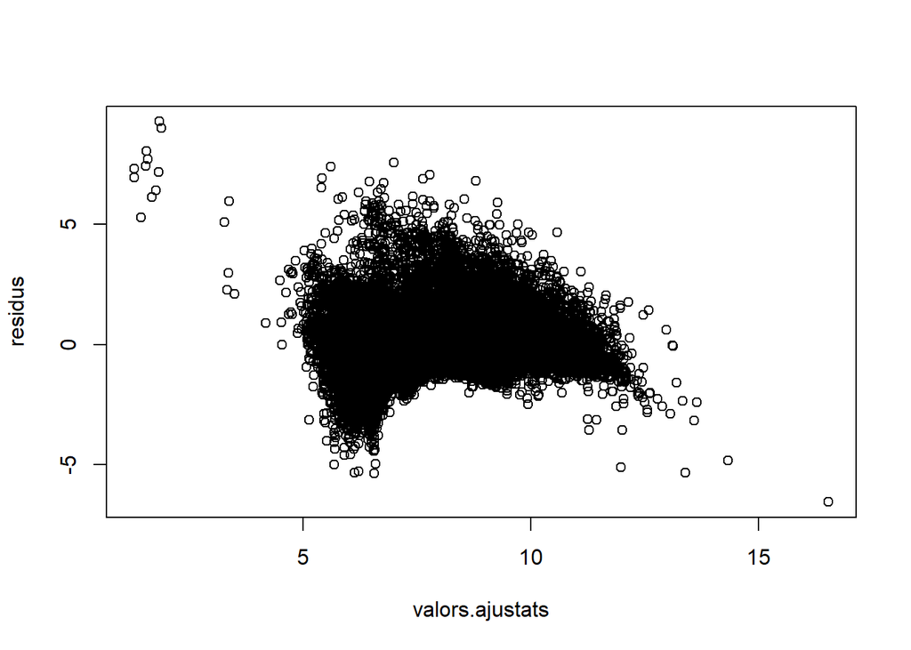

```r
residus <- rstandard(claimNet.model)
valors.ajustats <- fitted(claimNet.model)
plot(valors.ajustats, residus)
```

Veiem la dispersió del residus i podriem dir que el model no segueixi una dispersió aleatoria. Per tant, sembla que el model obtingut no s’ajusta bé a les dades mostrals.

### 4.2.2 QQPlot

Finalment hem executat QQ plot per saber si els errors és distribueixen de forma normal. En el mig del gràfic sembla que així sigui però es va convant en els extrems.

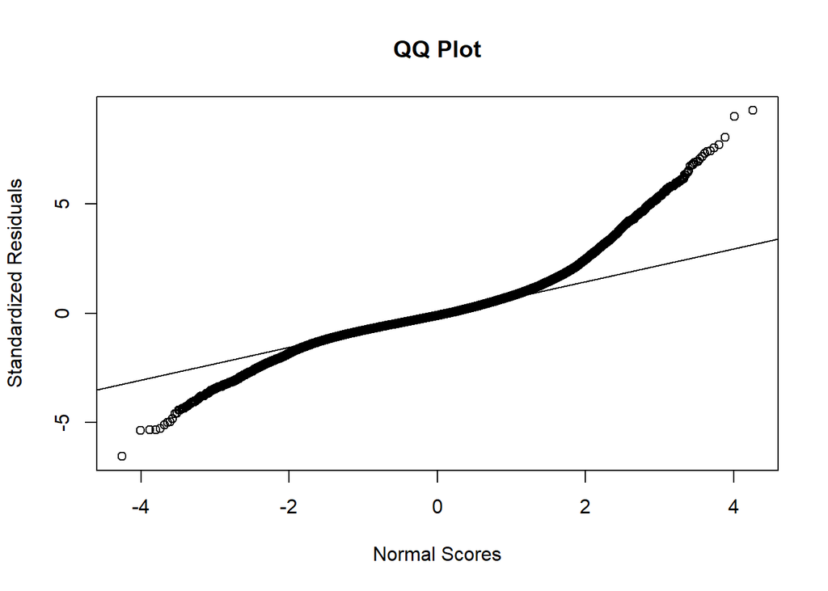

```r
model.stdres = rstandard(claimNet.model)
qqnorm(model.stdres,
     ylab="Standardized Residuals",
     xlab="Normal Scores",
     main="QQ Plot")
qqline(model.stdres)
```

Una altre forma de comprobar la normalitat és amb un gràfic de densitat a partir dels residus.

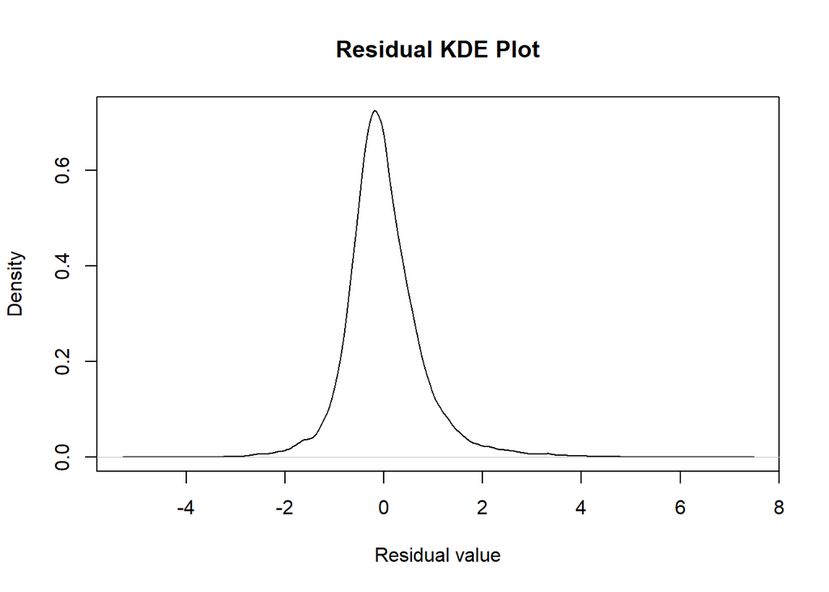

```r
d<-density(claimNet.model[['residuals']])
plot(d,main='Residual KDE Plot',xlab='Residual value')
```

Aquesta gràfica sembla que ens doni normalitat. Farem un contrast d’hipòtesi:

```r
lillie.test(claimNet.model$residuals)
```

```
##
##  Lilliefors (Kolmogorov-Smirnov) normality test
##
## data:  claimNet.model$residuals
## D = 0.07854, p-value < 2.2e-16
```

El valor per sota de 0.05 fa rebutjar la hipòtesi nul·la de normalitat i el que el nostre model sigui vàlid.

## 4.3 Predicció

Anem a realitzar una predicció amb el model que hem generat i les variables: Edad=24, Sexo= “F”, Estado=“S”, Dependientes=1, OtrosDepend=0, Salario=500, Jornada=“F”, HorasSemana=40, DiasSemana=5, Clasificacion=“Lent”, RiesgoSM=“TRUE” y CosteInicio=10000.

```r
data = data.frame(Edad=24, Sexo= "F", Estado="S", Dependientes=1, OtrosDepend=0, Salario=500, Jornada="F", HorasSemana=40, DiasSemana=5, Clasificacion="Lent", RiesgoSM="1", CosteInicio.log=log(10000))

predict(claimNet.model, data)
```

```
##        1
## 9.517933
```

```r
summary(claimNet.model)
```

```
##
## Call:
## lm(formula = CosteFinal.log ~ Edad + Sexo + Estado + Dependientes +
##     OtrosDepend + Salario + Jornada + HorasSemana + DiasSemana +
##     Clasificacion + RiesgoSM + CosteInicio.log, data = claimNet)
##
## Residuals:
##     Min      1Q  Median      3Q     Max
## -5.1107 -0.4414 -0.0821  0.3568  7.3049
##
## Coefficients:
##                           Estimate Std. Error t value Pr(>|t|)
## (Intercept)              1.525e+00  4.871e-02  31.297  < 2e-16 ***
## Edad                     4.466e-03  3.628e-04  12.310  < 2e-16 ***
## SexoM                   -1.423e-01  8.871e-03 -16.041  < 2e-16 ***
## EstadoS                 -3.836e-02  8.788e-03  -4.365 1.28e-05 ***
## Dependientes             4.265e-02  6.950e-03   6.136 8.51e-10 ***
## OtrosDepend              5.834e-02  3.251e-02   1.794 0.072773 .
## Salario                  6.697e-04  1.602e-05  41.802  < 2e-16 ***
## JornadaP                 5.649e-02  1.638e-02   3.448 0.000565 ***
## HorasSemana              4.032e-04  3.109e-04   1.297 0.194678
## DiasSemana              -5.559e-02  8.758e-03  -6.347 2.21e-10 ***
## ClasificacionMolt lent  -1.429e-02  1.414e-02  -1.010 0.312277
## ClasificacionMolt Rapid -1.583e-02  9.430e-03  -1.679 0.093255 .
## ClasificacionRapid       9.778e-03  9.194e-03   1.063 0.287583
## RiesgoSM1                1.892e-01  5.415e-02   3.494 0.000476 ***
## CosteInicio.log          8.273e-01  2.562e-03 322.927  < 2e-16 ***
## ---
## Signif. codes:  0 '***' 0.001 '**' 0.01 '*' 0.05 '.' 0.1 ' ' 1
##
## Residual standard error: 0.7901 on 48660 degrees of freedom
## Multiple R-squared:  0.7333, Adjusted R-squared:  0.7332
## F-statistic:  9555 on 14 and 48660 DF,  p-value: < 2.2e-16
```

```r
# calculem la desviació dels residuals
sd.res <- sd(claimNet.model$residuals)

# fem la predicció
pred <- exp(predict(claimNet.model, data) + (0.5 * sd.res))
pred
```

```
##        1
## 20190.15
```

La predicció del valor amb aquestes dades és de 20190.15.

# 5 Regressió logística

Anem a realitzar model de regressió logístic on es predigui si l’estimació inicial (CosteInicio) és inferior al pagat finalment. Aquesta variable de sortida serà la variable Deficit. El valor serà 1 si el cost final ha estat superior al inicial.

```r
claimNet$Deficit <- ifelse(claimNet$CosteInicio >= claimNet$CosteFinal, 0, 1)
```

## 5.1 Model predictiu

Realitzem el model predictiu amb les mateixes variables que en l’exercici anterior. Fem servir family=binomial(link=logit) ja que el resultat és binari.

```r
model.logist=glm(formula=Deficit ~ Edad + Sexo + Estado + Dependientes + OtrosDepend + Salario + Jornada + HorasSemana + DiasSemana + Clasificacion + RiesgoSM + log(CosteInicio), data = claimNet, family=binomial(link=logit))

summary(model.logist)
```

```
##
## Call:
## glm(formula = Deficit ~ Edad + Sexo + Estado + Dependientes +
##     OtrosDepend + Salario + Jornada + HorasSemana + DiasSemana +
##     Clasificacion + RiesgoSM + log(CosteInicio), family = binomial(link = logit),
##     data = claimNet)
##
## Deviance Residuals:
##     Min       1Q   Median       3Q      Max
## -5.4153  -1.1179   0.6951   0.9877   2.3301
##
## Coefficients:
##                           Estimate Std. Error z value Pr(>|z|)
## (Intercept)              3.926e+00  1.370e-01  28.648  < 2e-16 ***
## Edad                     1.122e-02  9.980e-04  11.241  < 2e-16 ***
## SexoM                   -3.755e-01  2.436e-02 -15.414  < 2e-16 ***
## EstadoS                 -6.871e-02  2.397e-02  -2.866  0.00415 **
## Dependientes             1.090e-01  1.999e-02   5.450 5.03e-08 ***
## OtrosDepend              1.719e-01  9.432e-02   1.822  0.06841 .
## Salario                  2.272e-03  5.416e-05  41.945  < 2e-16 ***
## JornadaP                 1.821e-01  4.528e-02   4.022 5.76e-05 ***
## HorasSemana             -6.938e-04  8.648e-04  -0.802  0.42240
## DiasSemana              -1.535e-01  2.448e-02  -6.270 3.61e-10 ***
## ClasificacionMolt lent  -9.411e-02  3.846e-02  -2.447  0.01441 *
## ClasificacionMolt Rapid -5.029e-02  2.564e-02  -1.961  0.04986 *
## ClasificacionRapid       4.595e-02  2.497e-02   1.840  0.06576 .
## RiesgoSM1                7.214e-02  1.475e-01   0.489  0.62480
## log(CosteInicio)        -4.902e-01  7.504e-03 -65.332  < 2e-16 ***
## ---
## Signif. codes:  0 '***' 0.001 '**' 0.01 '*' 0.05 '.' 0.1 ' ' 1
##
## (Dispersion parameter for binomial family taken to be 1)
##
##     Null deviance: 66399  on 48674  degrees of freedom
## Residual deviance: 60617  on 48660  degrees of freedom
## AIC: 60647
##
## Number of Fisher Scoring iterations: 4
```

Veiem que les variables amb un pes Pr(>|z|) < 0.05 significatives són, Edad, Sexo, Estado, Dependientes, Salario, Jornada, DiasSemana i log(CosteInicio). També podriem afegir, pero menys, quan la Clasificacion és ‘Molt Lent’, el tràmit és demora. També ho és el valor de la intersecció, quan totes les variables són 0. Les altres (p-valor > 0.05) no són significatives per al nostre model.

Veiem el valors que poden prendre els coeficients entre un 2.5 i 97.5% de confiança:

```r
confint(model.logist)
```

```
##                                2.5 %        97.5 %
## (Intercept)              3.657908270  4.195140e+00
## Edad                     0.009264379  1.317666e-02
## SexoM                   -0.423341323 -3.278380e-01
## EstadoS                 -0.115695386 -2.172678e-02
## Dependientes             0.069954654  1.483362e-01
## OtrosDepend             -0.010742879  3.594067e-01
## Salario                  0.002165891  2.378187e-03
## JornadaP                 0.093471025  2.709830e-01
## HorasSemana             -0.002390931  1.018559e-03
## DiasSemana              -0.201525545 -1.055729e-01
## ClasificacionMolt lent  -0.169446253 -1.868451e-02
## ClasificacionMolt Rapid -0.100554568 -3.767618e-05
## ClasificacionRapid      -0.002997769  9.489228e-02
## RiesgoSM1               -0.218430286  3.604544e-01
## log(CosteInicio)        -0.504983187 -4.755681e-01
```

I calculem els OR(Odds Ratio):

```r
exp(coefficients(model.logist))
```

```
##             (Intercept)                    Edad                   SexoM
##              50.7010526               1.0112821               0.6869197
##                 EstadoS            Dependientes             OtrosDepend
##               0.9335960               1.1151210               1.1875296
##                 Salario                JornadaP             HorasSemana
##               1.0022742               1.1997821               0.9993064
##              DiasSemana  ClasificacionMolt lent ClasificacionMolt Rapid
##               0.8577338               0.9101859               0.9509554
##      ClasificacionRapid               RiesgoSM1        log(CosteInicio)
##               1.0470212               1.0748035               0.6124767
```

Amb aquests OR podem dir, per exemple que Salario no és significativa ja que, encara que el p-valor era inferior a 0.05, amb un OR de 1 no afecta al resultat de Deficit. Passa similar amb la variable Edad. Coeficients amb valors al voltant de 1 no tenen un efecte sobre el resultat rellevant.

## 5.2 Interpretació

Anem a aplicar el test de Hosman-Lemeshow per a calcular la bondat de l’ajust.

Comparem els valors previstos (esperats) amb els observats. Fem un contrast d’hipòtesi on la nul·la ens diu que no hi ha diferències entre els valors per tant la alternativa indica que el model no és correcte.

```r
hoslem.test(claimNet$Deficit,fitted(model.logist))
```

```
##
##  Hosmer and Lemeshow goodness of fit (GOF) test
##
## data:  claimNet$Deficit, fitted(model.logist)
## X-squared = 282.78, df = 8, p-value < 2.2e-16
```

Amb el p-value < 0.05 rebutgem la hipòtesi nul·la amb el que el model no ajusta bé les dades.

Ara amb la corva ROC també verifiquem la qualitat del model. Si l’area de la corva s’apropa més a 1 el model és millor:

```r
prob=predict(model.logist, claimNet, type="response")
r=roc(claimNet$Deficit,prob, data=claimNet)
```

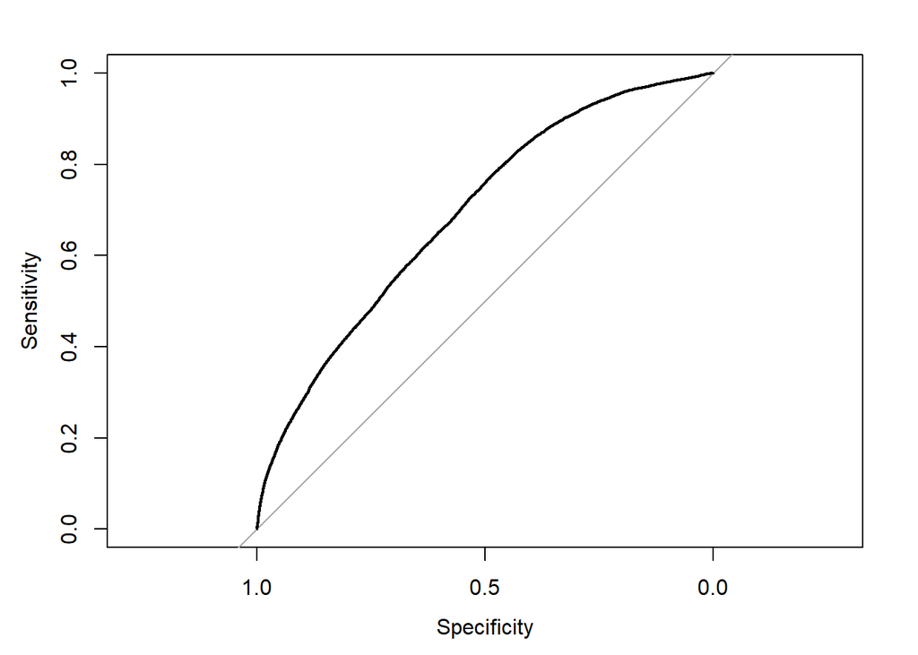

```r
plot(r)
```

```r
auc(r)
```

```
## Area under the curve: 0.6915
```

No tenim un model excessivament dolent encara que no és molt acurat. Segons el test de Hosman-Lemeshow podem dir que el model no seria correcte. La corva de ROC no és molt dolenta però.

## 5.3 Matriu de confusió

Anem a veure la matriu de confusió en la qual observarem la predicció del model. Considerem un 1 si la probabilitat >= 0.5 i 0 en cas contrari. Fem la comparació dels resultats amb la sortida real.

```r
pdata <- predict(model.logist, newdata = claimNet, type = "response")
pdata <- ifelse(pdata >= 0.5, 1, 0)
confusionMatrix <- confusionMatrix(data = as.factor(pdata) , reference = as.factor(claimNet$Deficit))
confusionMatrix
```

```
## Confusion Matrix and Statistics
##
##           Reference
## Prediction     0     1
##          0  9759  5900
##          1 10962 22054
##
##                Accuracy : 0.6536
##                  95% CI : (0.6493, 0.6578)
##     No Information Rate : 0.5743
##     P-Value [Acc > NIR] : < 2.2e-16
##
##                   Kappa : 0.2684
##
##  Mcnemar's Test P-Value : < 2.2e-16
##
##             Sensitivity : 0.4710
##             Specificity : 0.7889
##          Pos Pred Value : 0.6232
##          Neg Pred Value : 0.6680
##              Prevalence : 0.4257
##          Detection Rate : 0.2005
##    Detection Prevalence : 0.3217
##       Balanced Accuracy : 0.6300
##
##        'Positive' Class : 0
##
```

**La class positive és el valor 0**, és a dir, el cost final no és superior al inicial. A partir d’aquí veiem que:

```r
paste('True Positive:', confusionMatrix$table[1], '(hem predit 0 i hem encertat)')
```

```
## [1] "True Positive: 9759 (hem predit 0 i hem encertat)"
```

```r
paste('True Negative:', confusionMatrix$table[4], '(hem predit 1 i hem encertat)')
```

```
## [1] "True Negative: 22054 (hem predit 1 i hem encertat)"
```

```r
paste('False Positive:', confusionMatrix$table[3], '(hem predit 0 i hem errat)')
```

```
## [1] "False Positive: 5900 (hem predit 0 i hem errat)"
```

```r
paste('False Negative:', confusionMatrix$table[2], '(hem predit 1 i hem errat')
```

```
## [1] "False Negative: 10962 (hem predit 1 i hem errat"
```

```r
(confusionMatrix$table[1] + confusionMatrix$table[4]) / (confusionMatrix$table[1] + confusionMatrix$table[2] + confusionMatrix$table[3] + confusionMatrix$table[4])
```

```
## [1] 0.6535799
```

- Sensibilitat. De les classes positives, quantes hem predit correctament.

```r
confusionMatrix$table[1] / (confusionMatrix$table[1] + confusionMatrix$table[2])
```

```
## [1] 0.4709715
```

- Especificitat (Specificity). De les classes negatives, quantes hem predit correctament.

```r
confusionMatrix$table[4] / (confusionMatrix$table[4] +  confusionMatrix$table[3])
```

```
## [1] 0.788939
```

Tenim molt millor especifitat que sensibilitat. Amb aquest model ens és més fàcil trobar els negatius, és a dir, el casos en els quals el preu final és superior al inicial.

## 5.4 Predicció

Anem a predir la probabilitat per:

- Home
- 20 anys d’edat
- Solter
- sense fills
- Ni altres dependents
- Salari setmanal de 300 EUR
- Jornada partida,
- 30 hores setmanals
- 5 dies a la setmana
- Classificació del temps fins a l’obertura del sinistre de “Molt lent”
- Baixa que no és per salut mental
- Una valoració inicial de 10000 EUR

```r
data <- data.frame(Edad=20, Sexo='M',Estado='S',Dependientes=0,OtrosDepend=0,Salario=300,Jornada='P',HorasSemana=30,DiasSemana=5,Clasificacion='Molt lent',RiesgoSM='0',CosteInicio=log(10000))

pred<-predict(model.logist, data,type ="response")
pred
```

```
##         1
## 0.9307962
```

Amb les dades que hem esmentat tenim un valor molt proper a 1. Que el cost final sigui superior al inicial és realment és un valor molt clar.

# 6 Anàlisi de la variància (ANOVA) de un factor

Anem a fer un estudi per determinar si existeixen variacions en la variable CosteFinal en funció del temps que triga fins l’obertura.

Tenim un estudi d’un factor amb 4 tractaments, un per cada level de Clasificacion.

Podem veure primer gràficament si hi han diferencies entre els grups mitjançant un boxplot:

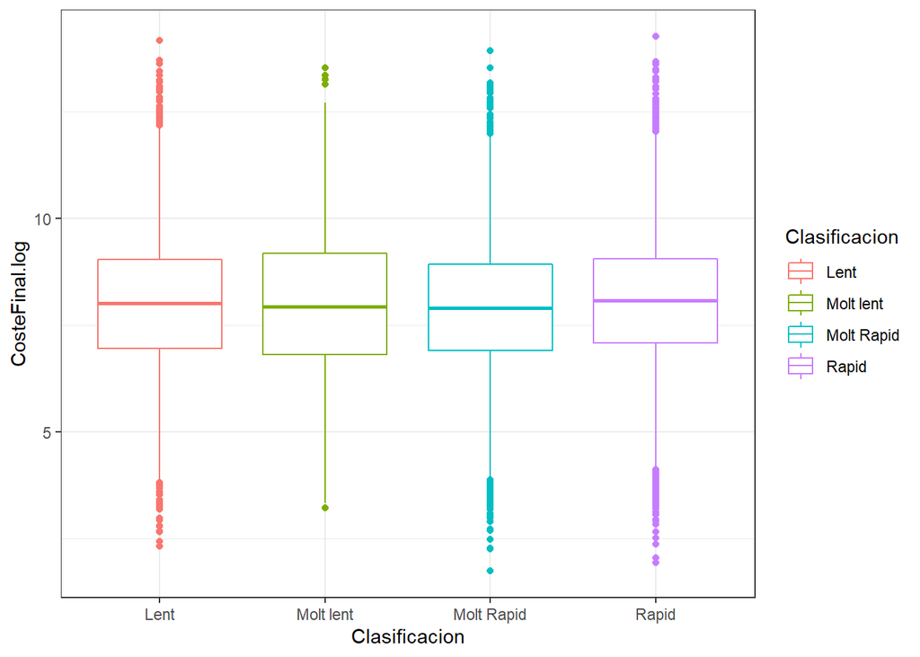

```r
ggplot(data = claimNet, aes(x = Clasificacion, y = CosteFinal.log, color = Clasificacion)) +
    geom_boxplot() +
    theme_bw()
```

En escala logarítmica no sembla que hi hagin moltes diferències entre els grups i podriem dir que ens trobem amb un model força equilibrat en quant a la normalitat i homocedasticitat.

## 6.1 Hipòtesi nul·la i alternativa

Com he comentat, ens preguntem si la variable Clasificacion, temps transcurregut fins l’opertura del sinistre, és significatiu en el CosteFinal.

Tenim doncs:

H0 - Hipòtesi nul·la: α1 = α2 = α3 = α4 = 0 H1 - Hipòtesi alternativa: αi != αj per algun i != j

Amb la hipòtesi nul·la acceptem que el factor Clasificacion no és significatiu, en canvi, la H1 implica el contrari.

## 6.2 Model

```r
model.logist2<-lm(CosteFinal.log ~ Clasificacion, data=claimNet)
anova <- anova(model.logist2)
anova
```

```
## Analysis of Variance Table
##
## Response: CosteFinal.log
##                  Df Sum Sq Mean Sq F value    Pr(>F)
## Clasificacion     3    190  63.293  27.092 < 2.2e-16 ***
## Residuals     48671 113707   2.336
## ---
## Signif. codes:  0 '***' 0.001 '**' 0.01 '*' 0.05 '.' 0.1 ' ' 1
```

Veiem que la variable de resposta és CosteFinal en escala logarítmica.

El p-valor és molt més petit que 0.05, per tant acceptem la alternativa en la qual es pot concloure que el factor és significatiu sobre la resposta. El temps en el qual es triga entre que es produeix el sinistre i s’obre l’expedient afecta al CosteFinal.

Podem saber el valor crític de F en el qual es delimita la zona de rebuig o acceptació amb un nivell de significança alfa de 0.05.

Tenim un valor de SSE molt gran, per tant deduïm que el model no ajusta prou bé.

```r
qf(0.05, nlevels(claimNet$Clasificacion) - 1, nrow(claimNet) - 1, lower.tail = F)
```

```
## [1] 2.605092
```

Valors per sobre de l’estadístic 2.605092 estaran a la zona de rebuig. En el nostre cas tenim un 27.092, molt per sobre.

Tenim una estimació centrada de la variança (MSE) de 2.336 i un MSA de 63.293. Per acceptar la H0 haurien de tenir un valor similar entre MSE i MSA. La divisió ens dona el valor F, si fos al voltant de 1 estariem en la zona d’acceptació. No és el cas.

```r
paste('El valor de F és: ', 63.293 / 2.336)
```

```
## [1] "El valor de F és:  27.0946061643836"
```

## 6.3 Efectes dels nivells del factor

Altre dada important és el valor de Sum Sq respecte els Residuals, la eta squared.

```r
190 / (190 + 113707)
```

```
## [1] 0.001668174
```

En aquest cas, el valor global de la eta-squared ens diu que no hi ha efecte entre les variables. El valor és molt baix.

## 6.4 Contrast dos-a-dos

Com que els factors principals han resultat significatius, farem comparacions per parelles per saber quins són els grups que generen les diferencies entre les mitjas de les poblacions. Ho fem amb el test de Tukey que trobem al package agricolae.

```r
hsd <- HSD.test(model.logist2, "Clasificacion", console = TRUE)
```

```
##
## Study: model.logist2 ~ "Clasificacion"
##
## HSD Test for CosteFinal.log
##
## Mean Square Error:  2.336238
##
## Clasificacion,  means
##
##            CosteFinal.log      std     r      Min      Max
## Lent             8.014673 1.542670 13589 2.334284 14.16842
## Molt lent        7.996111 1.634199  4060 3.234919 13.52911
## Molt Rapid       7.917190 1.503789 14789 1.746615 13.93241
## Rapid            8.072725 1.511404 16237 1.937128 14.26693
##
## Alpha: 0.05 ; DF Error: 48671
## Critical Value of Studentized Range: 3.63316
##
## Groups according to probability of means differences and alpha level( 0.05 )
##
## Treatments with the same letter are not significantly different.
##
##            CosteFinal.log groups
## Rapid            8.072725      a
## Lent             8.014673      b
## Molt lent        7.996111      b
## Molt Rapid       7.917190      c
```

Tenim un grup homogeni format per els levels Lent i Molt lent. Segurament en aquests casos és quan tenim una afectació en el cost final.

Ho veiem visualment. Veiem el grup b que hem comentat i uns altres dos formats per els levels Ràpid i Molt Ràpid.

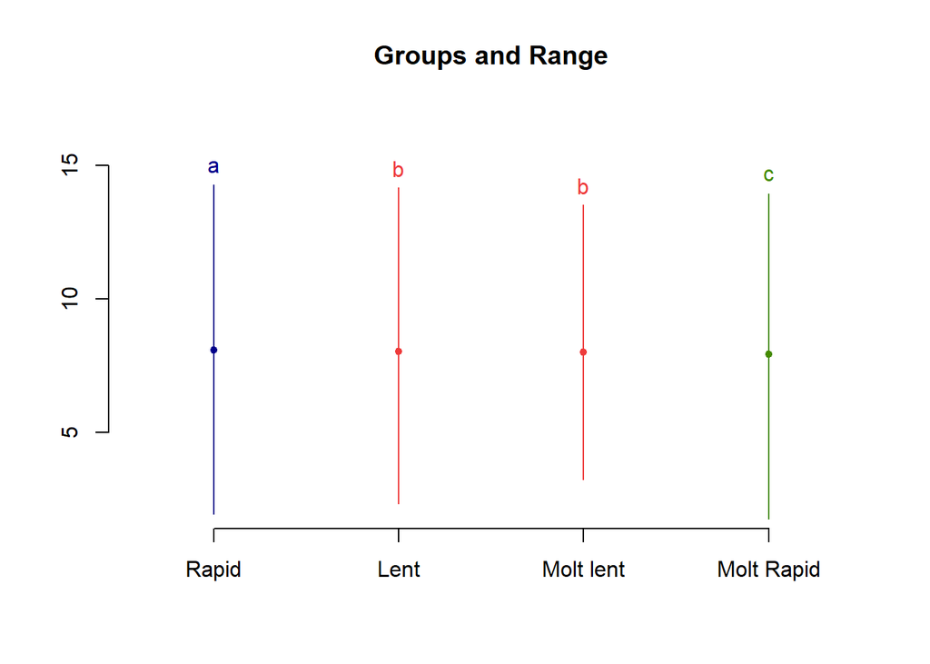

```r
plot(hsd)
```

## 6.5 Adequació del model

Anem a comprovar si el model és adeqüat a partir de la normalitat i homocedasticidad dels residus.

### 6.5.1 Normalitat dels residus

Farem diferents proves per veure si els residus tenen una distribució normal.

```r
summary(model.logist2$residuals)
```

```
##      Min.   1st Qu.    Median      Mean   3rd Qu.      Max.
## -6.170575 -1.026982 -0.000757  0.000000  1.025391  6.194203
```

Amb aquests valors, mean al voltant de 0, 1Q-3Q força simètrics i el mateix per Min i Max podem intuir normalitat.

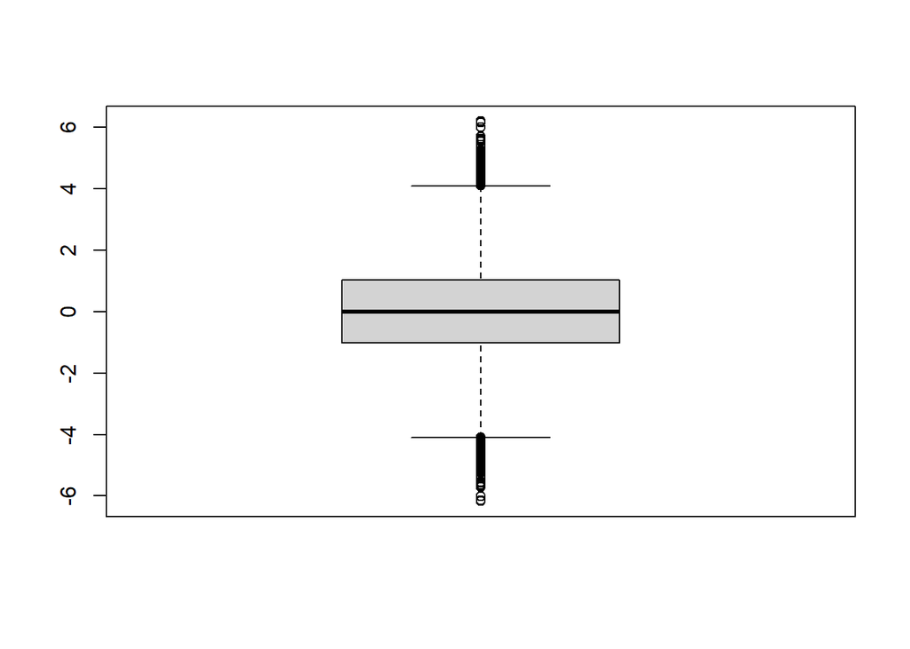

```r
boxplot(model.logist2$residuals)
```

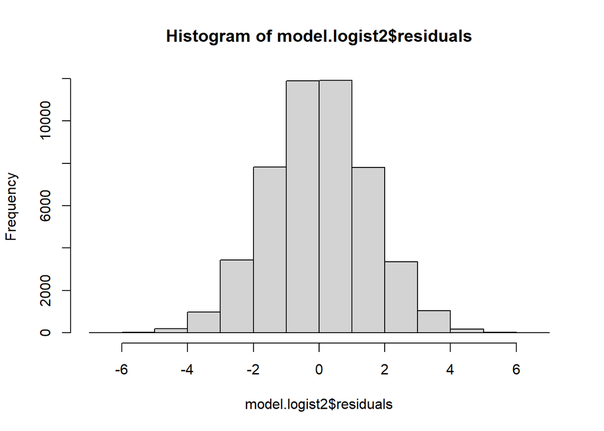

```r
hist(model.logist2$residuals)
```

Gràficament també sembla que tinguem normalitat. Però anem a fer la prova Q-Q plot per a confirmar-ho junt amb test de Shapiro.

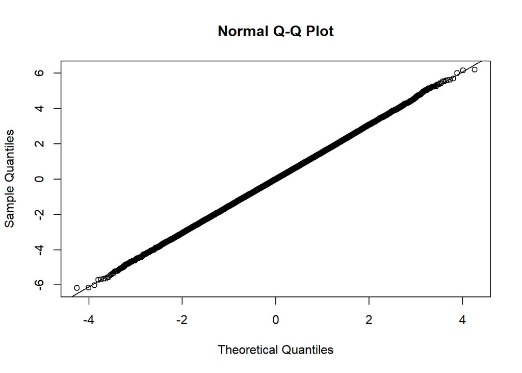

```r
qqnorm(model.logist2$residuals)
qqline(model.logist2$residuals)
```

Efectivament els resudis segueixen una distribució normal.

### 6.5.2 Homocedasticitat dels resudis

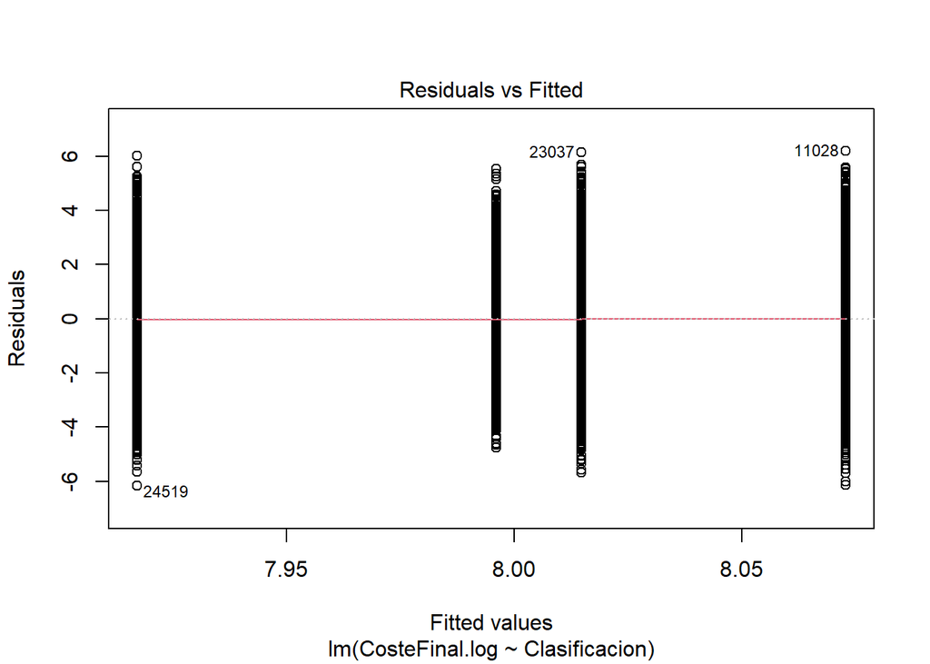

```r
plot(model.logist2, which=1)
```

Sembla que els grups segueixen homocedasticitat però ho haurem de comprovar amb un test Bartleet.

## 6.6 Cotrast de normalitat i homocedasticitat

Amb el test de Lilliefors (ja que la mostra > 5000 elements) comprovarem la normalitat. La H0 ens diu que els residus segueixen distribució normal, la H1 ho rebutja.

```r
lillie.test(model.logist2$residuals)
```

```
##
##  Lilliefors (Kolmogorov-Smirnov) normality test
##
## data:  model.logist2$residuals
## D = 0.0018258, p-value = 0.959
```

Amb un p-valor >> 0.05 no podem rebutjar la H0 (normalitat dels resudis) com ja havíem vist previament.

Amb el test de Bartlett comprovarem la homocedasticitat.

```r
bartlett.test(CosteFinal.log~Clasificacion,data=claimNet)
```

```
##
##  Bartlett test of homogeneity of variances
##
## data:  CosteFinal.log by Clasificacion
## Bartlett's K-squared = 52.145, df = 3, p-value = 2.789e-11
```

Amb un p-valor < 0.05, rebutjem la hipòtesi nul·la i no acceptem que les variàncies són iguals, tenim heterocedasticitat.

Com a possible sol·lució podem variar la resposta mitjançant una lambda per a obtenir una anova nova on els errors siguin mínims.

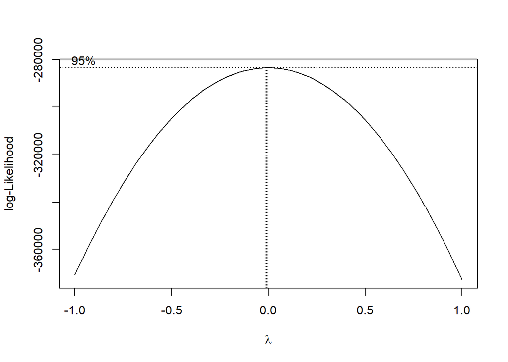

```r
boxcox<-boxcox(CosteFinal~Clasificacion,lambda = seq(-1, 1, length = 10),data=claimNet,plotit=T)
```

```r
lambda<-boxcox$x[which.max(boxcox$y)]
lambda
```

```
## [1] -0.01010101
```

```r
gm<-geometric.mean(claimNet$CosteFinal.log)
gm
```

```
## [1] 7.849213
```

```r
claimNet$CosteFinal.boxcox <-(claimNet$CosteFinal.log^lambda-1)/(lambda*gm^(lambda-1))

model.logist3<-lm(CosteFinal.boxcox ~ Clasificacion, data=claimNet)
anova <- anova(model.logist3)
anova
```

```
## Analysis of Variance Table
##
## Response: CosteFinal.boxcox
##                  Df Sum Sq Mean Sq F value    Pr(>F)
## Clasificacion     3    193  64.417  25.858 < 2.2e-16 ***
## Residuals     48671 121249   2.491
## ---
## Signif. codes:  0 '***' 0.001 '**' 0.01 '*' 0.05 '.' 0.1 ' ' 1
```

Nosaltres en un inici hem realitzat una transformació amb logaritme en base n. La transformació que hem obtingut mitjançant boxcox ens ha realitzat un guany en el residus despreciable. Realment no ens ha aportat gaire apart de la part didàctica.